# AS2019466

P.D. Navodya

2022-10-04

# **Covid-19 Pandemic in Nepal.**

## **1. Introduction.**

Corona Virus which is commonly known as COVID-19 is an infectious disease that causes illness in the respiratory system in humans. The term Covid 19 is sort of an acronym, derived from “Novel Corona Virus Disease 2019”.

Coronavirus (or COVID-19) was first identified in December 2019 in Wuhan city of China. In March 2020, the World Health Organisation (WHO) declared the Corona Virus outbreak a pandemic.

This pandemic has affected millions of peoples, who are either sick or are being killed due to the spread of this disease. This report gives us summary about confirmed cases, deaths and recovered cases of corona virus in Nepal from 2020.

### **1.1 Brief Introduction of Nepal**

Nepal is a landlocked country in South Asia and is bordered by China and India. It is located in the Himalayas and contains eight of the world’s ten highest peaks. It has a diverse geography, including fertile plains, subalpine forested hills, and eight of the world’s ten tallest mountains, including Mount Everest, the highest point on Earth. Nepal is a multi-ethnic, multi-lingual, multi-religious and multi-cultural state, with Nepali as the official language. Kathmandu is the nation’s capital angivd the largest city.

### **1.2 Location of Nepal**

Nepal is mainly situated in the Himalayas, but also includes parts of the Indo-Gangetic Plain, bordering Tibet of China to the north, and India in the south, east, and west, while it is narrowly separated from Bangladesh by the Siliguri Corridor, and from Bhutan by the Indian state of Sikkim.

**figure 01 : Location of Nepal in world map**

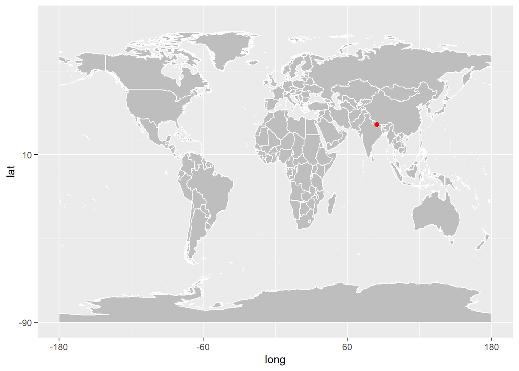

## **2. Exploratory Data Analysis.**

#### **2.1 Visualization of Confirmed cases, Deaths and Recoveries due to Covid-19 in Nepal.**

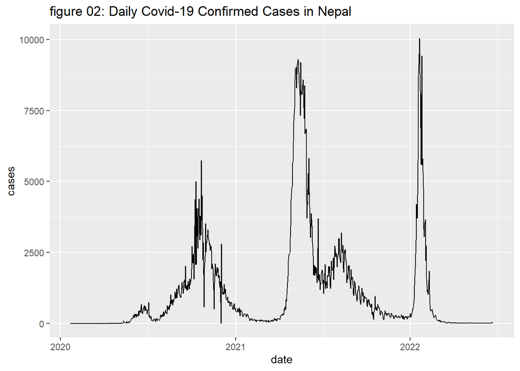

Figure 02 shows the number of confirmed cases of Covid-19 in Nepal over the time. At the beginning of the year 2020 there were no cases but from middle of the year 2020 it has began to increase rapidly. But from the end of the year 2020 it has began to decrease rapidly and then by the beginning of the year 2021 it has come closer to zero. But at the middle of the year 2021 it shows a sudden increase in the confirmed cases of Covid-19 and at the same time it shows a sudden decrease. And then it shows a small increase of confirmed cases after a few time, but it has began to decrease gradually and it has come closer to zero at the beginning of the year 2022. Then it again shows a sudden increase but at the same time it has decreased and has come closer to zero.

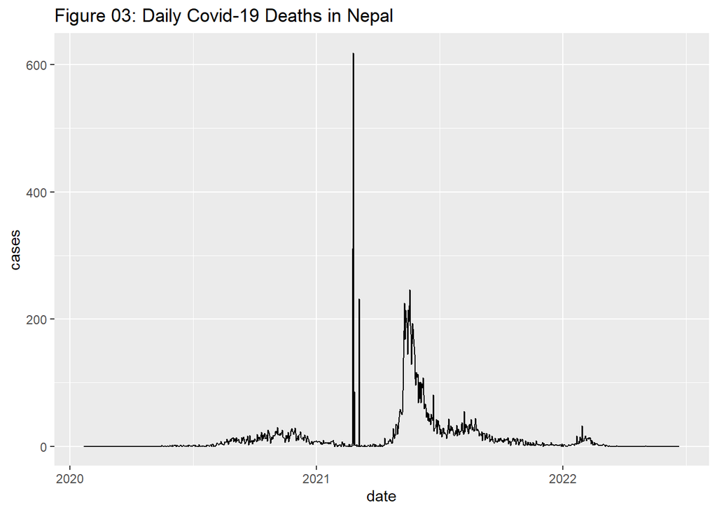

Figure 03 shows the number of deaths of Covid-19 in Nepal over the time.From the year 2020 to 2021 number of deaths are closer to zero. At the beginning of the year 2021 number of deaths shows a rapid increase, but at the same time it has decreased. Then by the middle of the year 2021 it shows a small increase and then it has began to decrease gradually and by the year 2022 it has come closer to zero.

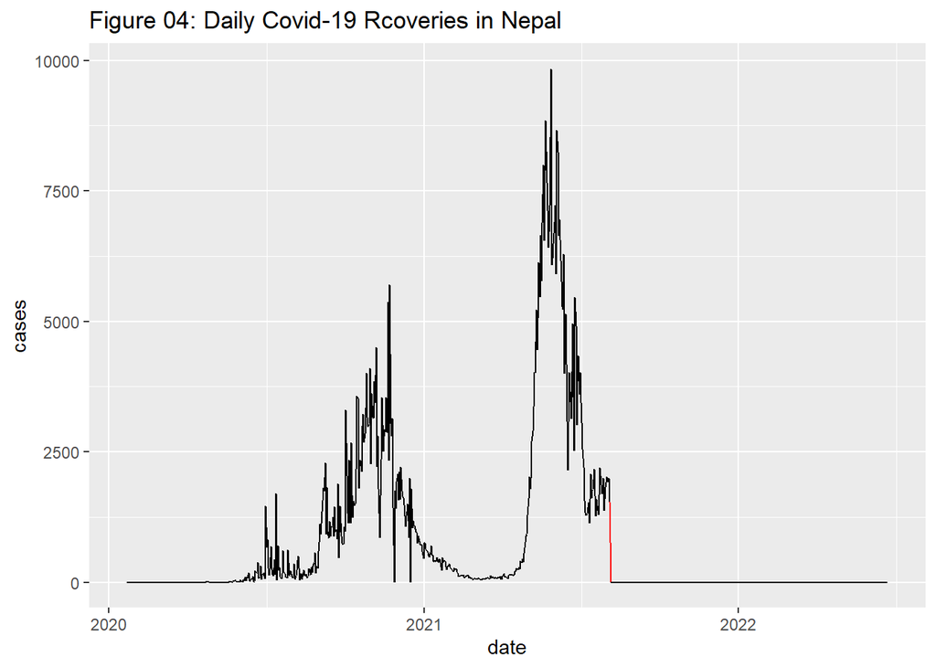

Figure 04 shows the number of recovered cases of Covid-19 in Nepal over the time. From the middle of the year 2020 number of recoveries has started to increase, but when it closer to the year 2021 number of recoveries has become started to decrease. And then again by the middle of the year 2021 number of recoveries shows a sudden increase and then it has started to decrease rapidly.

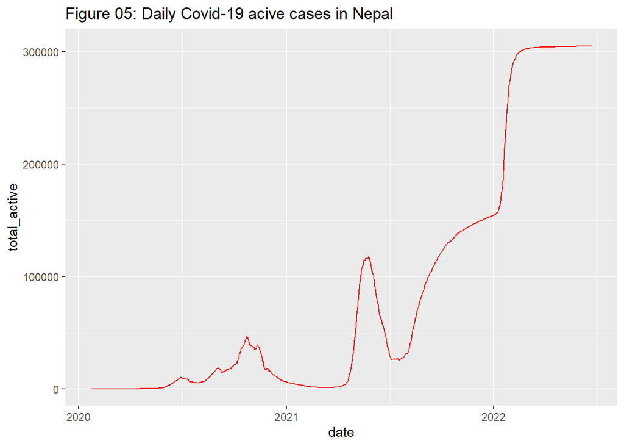

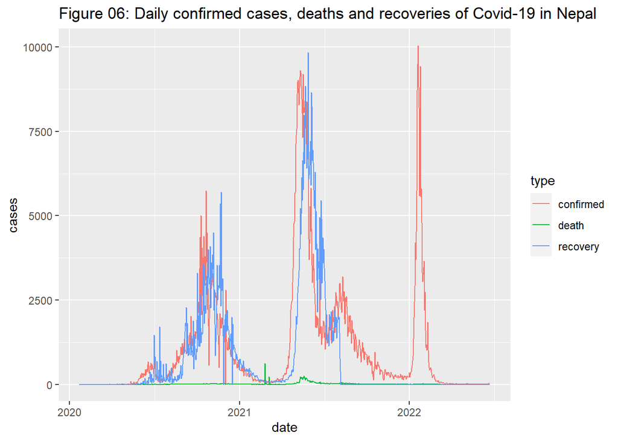

Figure 06 shows the number of confirmed cases, deaths and recoveries of Covid-19 in Nepal from year 2020 to 2022. Number of deaths shows a value closer to zero over this time period and it is lower than both of the number of confirmed cases and number of recoveries. From year 2020 to middle of the year 2021 number of confirmed cases and number of recoveries shows a same variation, and after that number of recoveries has become closer to zero while number of confirmed cases shows a sudden increase at the beginning of the year 2022.

### **2.2 Comparison of Covid-19 Status in Nepal with Neighbouring Countries.**

**Figure 07**

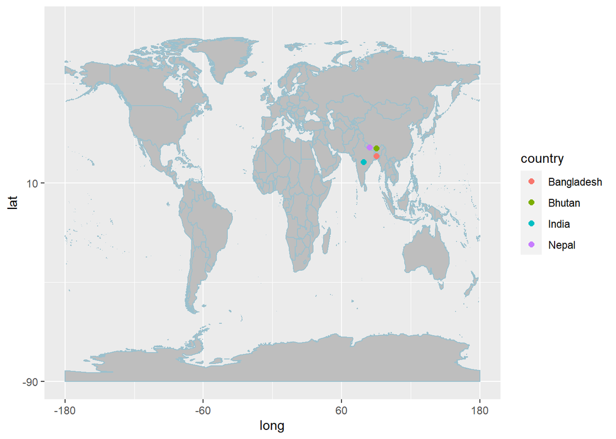

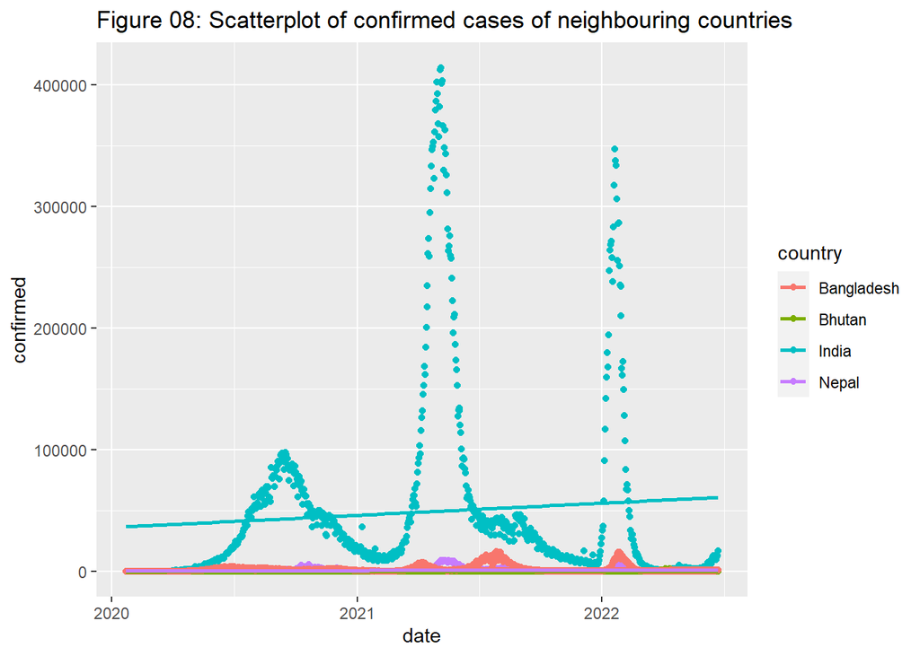

Figure 08 shows the variation of Covid-19 confirmed cases of Nepal with its neighbouring countries. Variation of the confirmed cases of the countries Bangladesh and Bhutan are very similar to the variation of the confirmed cases of Nepal while variation of confirmed case of India shows a different variation than Nepal,Bhutan And Bangladesh. And also confirmed cases of India is very higher than Nepal,Bangladesh and Bhutan over the whole time period.

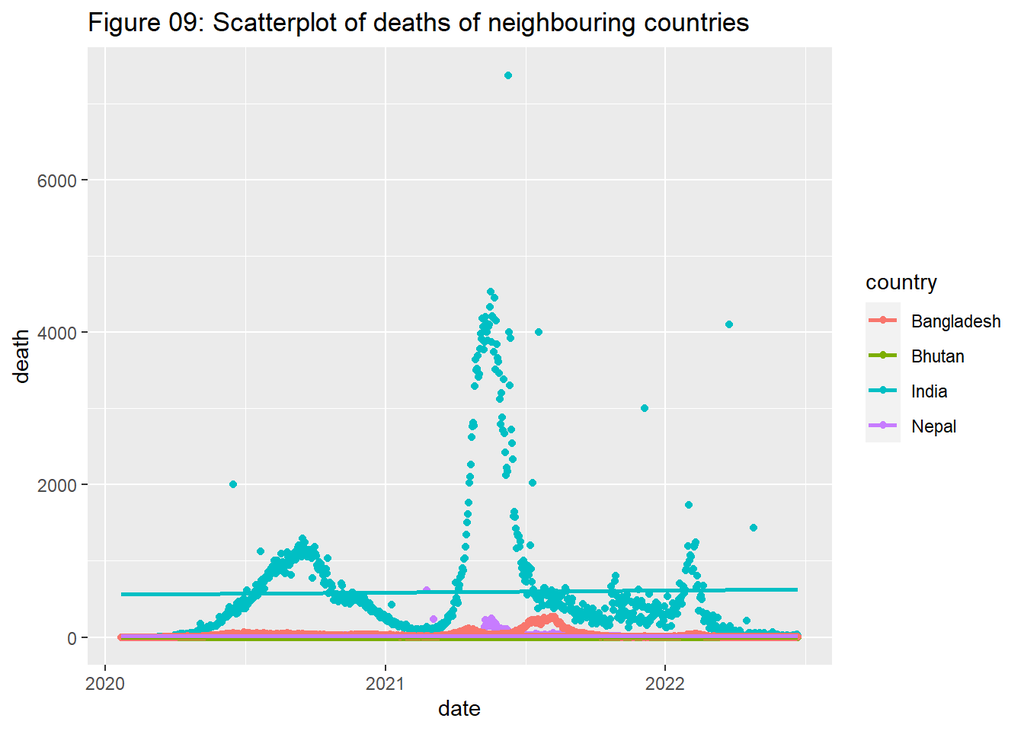

Figure 09 shows the variation of Covid-19 deaths of Nepal with its neighbouring countries. Variation of the deaths of the countries Bangladesh and Bhutan shows a very similar variation to the variation of deaths of Nepal while variation of deaths of India is differ than Nepal,Bhutan And Bangladesh. And also deaths of India is higher than Nepal,Bangladesh and Bhutan over the whole time period.

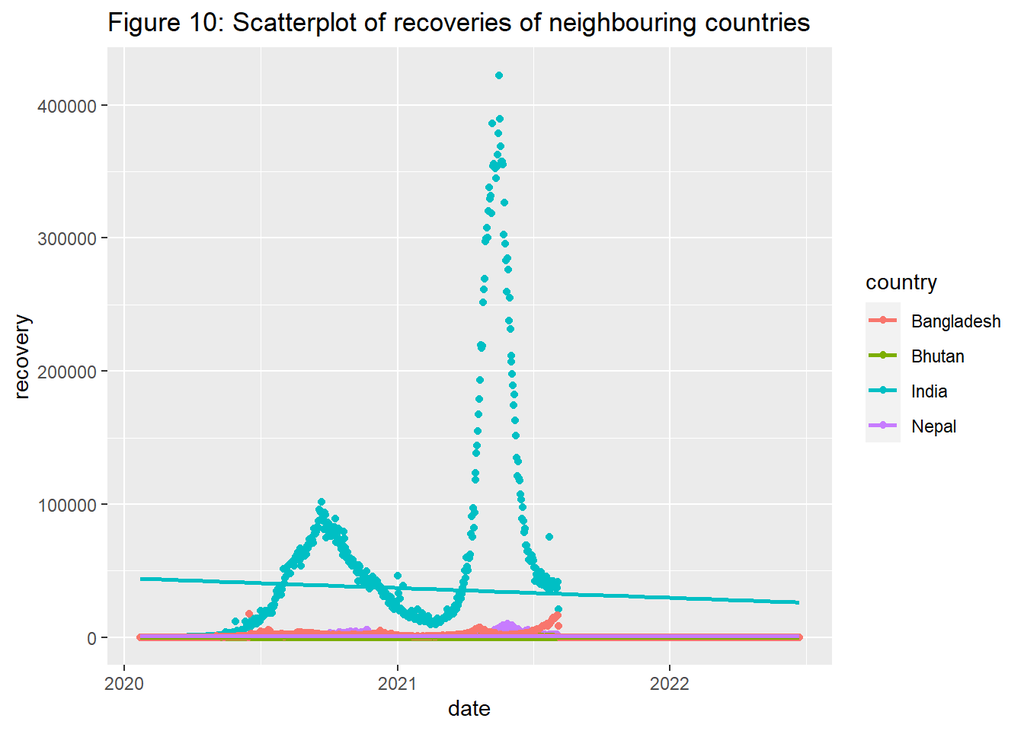

## **4. References.**

https://en.wikipedia.org/wiki/Nepal

https://hellor.netlify.app